# Reproducibility Studies of From the Viscera to First Impressions:Phase-Dependent Cardio-Visual Signals Bias the Perceived Trustworthiness of Faces

Shen tong

1  
1306999536@qq.com

Xi yue

1  
1348539779@qq.com

Yao meng han

1  
Meghanyao@163.com

Abstract

When we see new people, we rapidly form first impressions. Whereas past research has focused on the role of morphological or emotional cues, we asked whether transient visceral states bias the impressions we form. Across three studies (N = 94 university students), we investigated how fluctuations of bodily states, driven by the interoceptive impact of cardiac signals, influence the perceived trustworthiness of faces. Participants less often chose faces presented in synchrony with their own cardiac systole as more trustworthy than faces presented out of synchrony. Participants also explicitly judged faces presented in synchrony with their cardiac systole as less trustworthy. Finally, the presentation of faces in synchrony with participants’ cardiac diastole did not modulate participants’ perceptions of the faces’ trustworthiness, suggesting that the systolic phase is necessary for such interoceptive effects. These findings highlight the role of phasic interoceptive information in the processing of social information and provide a mechanistic account of the role of visceroception for social perception.

```r
# 检查是否已安装 pacman
if (!requireNamespace("pacman", quietly = TRUE)) {
  install.packages("pacman") }   # 如果未安装，则安装包

# 使用p_load来载入需要的包
pacman::p_load("readxl", "car", "lme4", "emmeans", "effects", "tidyverse", "ggplot2", "ggdist", "pwr","tidybayes","bibtex","papaja","knitr","pandoc")

TR <- read_excel("R_trust_2faces_for_mm.xlsx")
T2 <- read_excel("Data_JOTandJOTD_mm.xlsx")
T3 <- read_excel("Data_JOTD_Study3.xlsx")
T23<- read_excel("Data_JOTandJOTD_mm.xlsx")
p <- list()
```

##Introduction

The formation of first impressions when we see new faces shapes our social interactions as we appraise others on the basis of their facial appearance. An important aspect of such appraisals relates to perceived trustworthiness[@kapfer_experience-dependent_2002].One way to study the impact of visceral signals on cognition is to synchronize the presentation of stimuli with the participants’ physiological rhythms[@azevedo_viscera_2023].

Past research has mainly focused on morphological or emotional cues of facial appearance, researchers here turned their attention to how visceral states that are interoceptively perceived can bias our first impressions, focused on whether and how cardiac afferent signals can influence the first impressions of trustworthiness, with the aim of providing a mechanistic account of the role of visceroception for face and social perception.

Researchers implemented a cardio-visual stimulation paradigm to study the influence of transient interoceptive states on the perceived trustworthiness of new faces across three studies.

In Studies 1(35 volunteers) and 2(30 volunteers),Participants judged the perceived trustworthiness of faces flashing either in frequency and phase synchrony (i.e., at systole) with their own heartbeats (systole-self condition) or following someone else’s previously recorded heart rhythms (other-hearts conditions).In Study 3( 29 volunteers),followed the same paradigm but with a constant phase shift in the cardio-visual synchrony to coincide with cardiac diastole (diastole-self condition), rather than systole, to test whether the cardiac influence is dependent on the phase of the cardiac cycle.

Following the known cardiac cycle modulation of saliency networks in the brain and the increased sensitivity to motivationally salient and threat-signaling stimuli (Garfinkel et al., 2014), researches predicted reduced trustworthiness during synchronous cardio-visual stimulation. Moreover, we predicted that this effect would be cardiac-phase specific (i.e., synchronous with systole) rather than simply frequency dependent (i.e., synchronous with either systole or diastole). They expected the bodily signals of arousal conveyed at systole to selectively increase vigilance or sensitivity to salient social stimuli, which in this context of threat-related judgments would lead to increased perceptions of untrustworthiness.

Finally, face presentation synchronized with participants’ cardiac diastole was found not to moderate subjects’ perception of face credibility, suggesting that systole is necessary for this entrainment effect.

In this paper we will follow the authors’ research ideas and intentions to replicate and supplement the data according to three experiments, mainly using descriptive statistics, regression and analysis of variance.

#Study 1

## Participants

A total of 35 volunteers (age: M = 22.6 years, SD = 3.4; 27 females) were recruited via the departmental subject pool. Calculations in G*Power (Version3.1; Faul et al., 2007), based on a previous study of cardiac gating on emotional valence (Garfinkel et al., 2014),indicated that a sample size of 35 would be needed to obtain an effect size (f 2 ) of .40 at a power of 85% with an α of .05, which is consistent with other studies in the field (Azevedo et al., 2018; Li et al., 2020). The study was approved by the Royal Holloway University of London Department of Psychology ethics committee, and written informed consent was obtained from all participants.

## Material and Procedure

Stimuli consisted of images (400 × 477 pixels) of computer-generated Caucasian male faces with neutral facial expressions against a black background (Oosterhof & Todorov, 2008). The faces were created using FaceGen (Version 3.1; http://facegen.com) by the Social Perception Lab at Princeton University (https://tlab.uchicago .edu/databases/) to vary along the dimension of trustworthiness. The selected stimuli set comprised a total of 150 different images consisting of 25 different face identities, each of them with six versions that varied in trustworthiness by increments of 1 standard deviation. The face masks were created by maintaining the shape of the faces but replacing them with pixel-size black-and-white random noise.

Three disposable ECelectrodes were placed in a modified lead I chest configuration: Two electrodes were positioned underneath the left and right collarbone, and another was placed onthe participant’s lower back on the left side. The ECG signal was recorded at 1000 HZ (band-pass filtered between 0.3 and 1000 Hz) with a PowerLab 8/35 data acquisition device using LabChart 8 Pro software (ADInstruments). Heartbeats were detected on-line with a hardwarebased function (fast output response; ADInstruments), which identifies the ECG’s R-wave with a delay smaller than 1 ms when the amplitude exceeds an individually defined threshold. In the systole-self condition, pictures were presented at R + 200 ms (Azevedo et al., 2015; Sel et al., 2017) to coincide with the cardiac systole and the period of maximal representation of arterial baroreceptors in the brain. Other heart rhythms consisted of prerecorded interbeat intervals of previous participants performing a similar task (Azevedo et al., 2015) and were adjusted on each trial to be 8% faster or slower than the participant’sheart, as estimated during the preceding trial. In otherslow versus other-fast trials, the average heart rhythms were 4% slower and faster, respectively, than the participants’ own heart to maintain the 8% relative difference between the two rhythms. The other-hearts database contained several different heartbeat samples from distinct participants, and each trial presented a random portion of one of these samples. Thus, no other-heart trials had exactly the same heart rate variability.

## Data analysis

We used R [Version 4.2.2; @R-base] for all our analyses. The results from Frequentist hypothesis testing (i.e., ANOVA) will be reported below.

```r
pacman::p_load("readxl","car","lme4","emmeans","effects","reshape2","plyr","pwr","psy","tidyr","effectsize","tidyverse","ggplot2","ggdist","RColorBrewer","ggridges","dplyr")
```

##Data preprocessing

```r
#读取数据
TR <- read_excel("R_trust_2faces_for_mm.xlsx")
str(TR)
```

```
## tibble [6,300 × 8] (S3: tbl_df/tbl/data.frame)
##  $ part     : num [1:6300] 1 1 1 1 1 1 1 1 1 1 ...
##  $ trial    : num [1:6300] 1 1 2 2 3 3 4 4 5 5 ...
##  $ choice   : num [1:6300] 0 1 1 0 1 0 1 0 0 1 ...
##  $ cond     : num [1:6300] 2 1 3 2 3 2 2 1 3 1 ...
##  $ otherCond: num [1:6300] 1 2 2 3 2 3 1 2 1 3 ...
##  $ trust    : num [1:6300] 2 2 1 1 1 1 0 0 3 3 ...
##  $ pic      : num [1:6300] 14 5 12 7 9 5 9 21 10 6 ...
##  $ otherPic : num [1:6300] 5 14 7 12 5 9 21 9 6 10 ...
```

```r
head(TR,5)
```

```
## # A tibble: 5 × 8
##    part trial choice  cond otherCond trust   pic otherPic
##   <dbl> <dbl>  <dbl> <dbl>     <dbl> <dbl> <dbl>    <dbl>
## 1     1     1      0     2         1     2    14        5
## 2     1     1      1     1         2     2     5       14
## 3     1     2      1     3         2     1    12        7
## 4     1     2      0     2         3     1     7       12
## 5     1     3      1     3         2     1     9        5
```

```r
#预处理
df_sum <- TR %>%
  dplyr::mutate(cond = case_when(cond == "1" ~ "Self",
                                  cond == "2" ~ "Other-Slow",
                                  cond == "3" ~ "Other-Fast")) %>%

  dplyr::group_by(cond) %>%
  dplyr::ungroup()
```

##Calculation of sample size_single factor within subjects

```r
pwr.anova.test(k = 3, n = NULL, f = 0.40, sig.level = 0.05,power = 0.85)
```

```
##
##      Balanced one-way analysis of variance power calculation
##
##               k = 3
##               n = 23.78543
##               f = 0.4
##       sig.level = 0.05
##           power = 0.85
##
## NOTE: n is number in each group
```

##Descriptive_analysis_plot

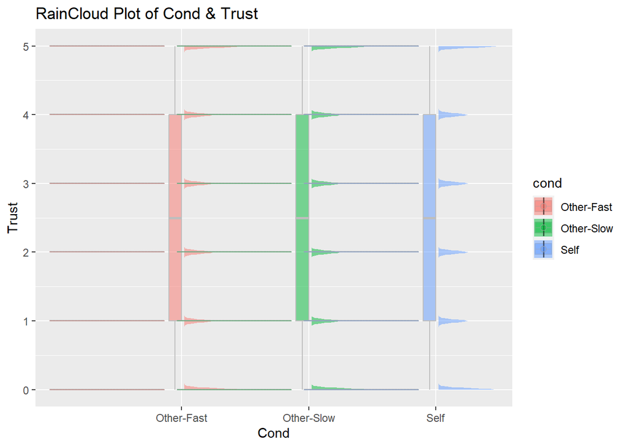

```r
p1 <- ggplot2::ggplot(df_sum, aes(x = cond, y = trust, fill = cond,)) +
  ggplot2::geom_boxplot(width = 0.1, position = position_nudge(x = -0.05), color = "grey", alpha = 0.5, outlier.color = NA,) +
  ggdist::stat_halfeye(adjust = 0.2,justification = -0.05, alpha = 0.5, width = 0.5, .width = 0, point_colour = NA) +
  ggdist::stat_dots(side = "left",justification = 1.15, alpha = 0.5) +
  ggplot2::labs(x = "Cond", y = "Trust", title =  "RainCloud Plot of Cond & Trust")
p1
```

```r
ggsave(filename = "./picture/plot1.png", plot = p1, height = 5, width = 10, dpi = 300)
```

##Model Comparison

```r
#将part、cond、pic和choice四列数据类型分别转换为因子型数据
TR$part<-factor(TR$part)
TR$cond<-factor(TR$cond)
TR$pic<-factor(TR$pic)
TR$choice<-factor(TR$choice)

#标准化trial列的数据，使其均值为0，标准差为1
TR$trial<-scale(TR$trial,center=TRUE,scale= TRUE)

#模型比较
m1=glmer(choice~ (1|pic),data=TR,family='binomial')
##使用lme4包的glmer()函数进行模型拟合，choice作为因变量，pic作为随机效应，表示每个被试重复测试的数据在不同的图片上进行了多次数据采集。binomial表示因变量choice是二项分布。
m2=glmer(choice~ (1|pic)+(1|part),data=TR,family='binomial')
```

```
## boundary (singular) fit: see help('isSingular')
```

```r
##将choice作为因变量，pic和part均作为随机效应，表示每个被试重复测试的数据在不同的图片和不同的受试者之间进行了多次数据采集。
anova(m1,m2)
```

```
## Data: TR
## Models:
## m1: choice ~ (1 | pic)
## m2: choice ~ (1 | pic) + (1 | part)
##    npar    AIC    BIC  logLik deviance Chisq Df Pr(>Chisq)
## m1    2 8440.4 8453.9 -4218.2   8436.4
## m2    3 8442.4 8462.7 -4218.2   8436.4     0  1          1
```

```r
#logistic回归分析
m2=glmer(choice~cond+ (1|pic), data=TR,family='binomial')
##进行有条件的logistic回归分析，将cond变量作为独立变量，以choice作为因变量，pic作为随机效应，执行了不带交互项的回归分析。
m3=glmer(choice~cond+trust+(1|pic), data=TR,family='binomial')
##将cond和trust变量作为独立变量，以choice作为因变量，pic作为随机效应，执行了带交互项的回归分析。
m4=glmer(choice~cond+cond:trust+(1|pic), data=TR,family='binomial')
##将cond和trust变量作为独立变量，以choice作为因变量，pic作为随机效应，执行了带交互项且包含条件项的回归分析。
anova(m1,m2,m3,m4)
```

```
## Data: TR
## Models:
## m1: choice ~ (1 | pic)
## m2: choice ~ cond + (1 | pic)
## m3: choice ~ cond + trust + (1 | pic)
## m4: choice ~ cond + cond:trust + (1 | pic)
##    npar    AIC    BIC  logLik deviance  Chisq Df Pr(>Chisq)
## m1    2 8440.4 8453.9 -4218.2   8436.4
## m2    4 8436.0 8462.9 -4214.0   8428.0 8.4701  2    0.01448 *
## m3    5 8438.0 8471.7 -4214.0   8428.0 0.0003  1    0.98590
## m4    7 8438.5 8485.8 -4212.3   8424.5 3.4091  2    0.18186
## ---
## Signif. codes:  0 '***' 0.001 '**' 0.01 '*' 0.05 '.' 0.1 ' ' 1
```

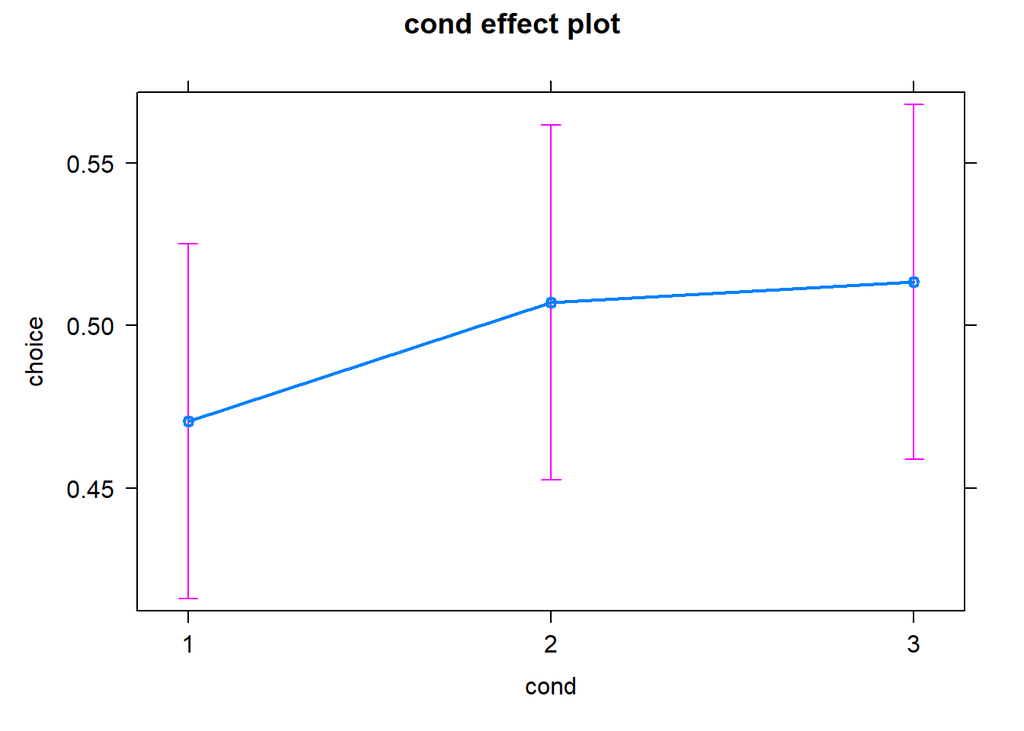

```r
##在m1、m2、m3、m4四个模型之间进行比较。
plot(allEffects(m2))
```

```r
##使用effects包的allEffects()函数，进行单变量条件效应的绘图（即只考虑cond做出的影响）。

#线性混合模型检验
emm_options(pbkrtest.limit = 6100)
##设置参数pbkrtest.limit的值为6100
emmeans(m2, list(pairwise ~ cond), adjust = "none")
```

```
## $`emmeans of cond`
##  cond  emmean    SE  df asymp.LCL asymp.UCL
##  1    -0.1181 0.112 Inf    -0.337     0.101
##  2     0.0282 0.112 Inf    -0.190     0.247
##  3     0.0539 0.112 Inf    -0.165     0.273
##
## Results are given on the logit (not the response) scale.
## Confidence level used: 0.95
##
## $`pairwise differences of cond`
##  1             estimate     SE  df z.ratio p.value
##  cond1 - cond2  -0.1463 0.0637 Inf  -2.297  0.0216
##  cond1 - cond3  -0.1720 0.0638 Inf  -2.698  0.0070
##  cond2 - cond3  -0.0257 0.0636 Inf  -0.403  0.6867
##
## Results are given on the log odds ratio (not the response) scale.
```

```r
##对于混合效应模型m2，进行emmeans算法计算，即表示求出每种cond情况下choice的期望数值(estimate)、标准误(SE)、置信区间(CI)以及截距项和cond的系数估计值。pairwise~cond表示要求计算cond各水平之间的差异。adjust="none"表示不应用p-value方法对均值进行显著性调整（即只是展示每个条件下的比较结果，不进行多重比较校验）。
```

#Study 2

## Methods

we presented only one face at a time and asked participants to judge the perceived trustworthiness of each face . Lower ratings to faces synchronized with the participants’ heartbeats would provide a conceptual replication of Study 1 and rule out the possibility that the previously observed effects were driven by attention competition between the two faces.

## Data analysis

We used R [Version 4.2.2; @R-base] for all our analyses. The results from Frequentist hypothesis testing (i.e., ANOVA) will be reported below.

## Results

```r
library(readxl)
library(car)
library(lme4)
library(emmeans)
library(effects)

library(tidyverse)
library(ggplot2)
library(ggdist)
library(tidybayes)

pacman::p_load("tidyverse", "faux", "pwr", "MASS", "afex")
```

##open data

```r
TR <- read_excel("R_trust_2faces_for_mm.xlsx")
T2 <- read_excel("Data_JOTandJOTD_mm.xlsx")
T3 <- read_excel("Data_JOT_Study2.xlsx")
p <- list()

T2$part<-factor(T2$part)
T2$heart<-factor(T2$heart)
T2$pic<-factor(T2$pic)
T2$study=factor(T2$study)

TR$trial<-scale(TR$trial,center=TRUE,scale= TRUE)
```

##Data preprocessing

```r
T2 <- read_excel("Data_JOTandJOTD_mm.xlsx")
T2.1 <- T2 %>%
  dplyr::select(`part`,
                `trial`,
                `heart`,
                `trust`,
                `rating`,
                `pic`,
                `study`,
                ) %>%
  dplyr::filter(study == 2)%>%
  dplyr::mutate(heart = case_when(heart == "1" ~ "Self Heart",
                                  heart == "2" ~ "Other-Slow",
                                  heart == "3" ~ "Other-Fast")) %>%
  dplyr::group_by(heart,rating) %>%
    dplyr::ungroup()
head(T2.1, 5)
```

```
## # A tibble: 5 × 7
##    part trial heart      trust rating pic              study
##   <dbl> <dbl> <chr>      <dbl>  <dbl> <chr>            <dbl>
## 1     1     1 Self Heart     2     84 'fi_008_tw2.jpg'     2
## 2     1     2 Other-Slow     5     67 'fi_018_tw5.jpg'     2
## 3     1     3 Other-Fast     1     41 'fi_024_tw1.jpg'     2
## 4     1     4 Other-Fast     3     56 'fi_016_tw3.jpg'     2
## 5     1     5 Other-Slow     3     65 'fi_023_tw3.jpg'     2
```

##Calculation of sample size_single factor within subjects

```r
pwr.anova.test(k = 3, n = NULL, f = 0.32, sig.level = 0.05,power = 0.95)#通过代码分析，发现研究2 中的被试数量不够，明显少于所需人数。
```

```
##
##      Balanced one-way analysis of variance power calculation
##
##               k = 3
##               n = 51.28505
##               f = 0.32
##       sig.level = 0.05
##           power = 0.95
##
## NOTE: n is number in each group
```

##Image color

```r
popsicle <- c("#F3533A", "#FA9F42", "#8AD879", "#5ACFC9")
sunset <- c("#C848B9", "#F962A7", "#FD836D", "#FFBA69")
glassdoor <- c("#3D9A8B", "#2EB19F", "#63C2D2", "#B7EDFF")
palette <- list(popsicle = popsicle, sunset = sunset, glassdoor = glassdoor)
rm(popsicle, sunset, glassdoor)
```

##Descriptive Statistics Chart

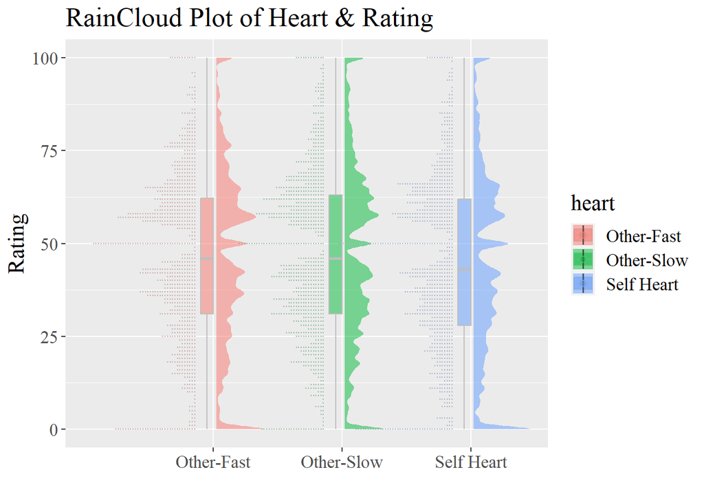

```r
p[[1]] <- ggplot2::ggplot(T2.1, aes(x = heart, y = rating, fill = heart)) +
  ggplot2::geom_boxplot(width = 0.1, position = position_nudge(x = -0.05), color = "grey", alpha = 0.5, outlier.color = NA,) + # 箱线图左移0.2个单位
  ggdist::stat_halfeye(adjust = 0.2,justification = -0.05, alpha = 0.5, width = 0.5, .width = 0, point_colour = NA) +
  ggdist::stat_dots(side = "left",justification = 1.15, alpha = 0.5) +
  ggplot2::labs(x = "", y = "Rating", title =  "RainCloud Plot of Heart & Rating")
names(p)[1] <- "RainCloud Plot"; p[[1]]+theme(text=element_text(size=16,  family="serif"))
```

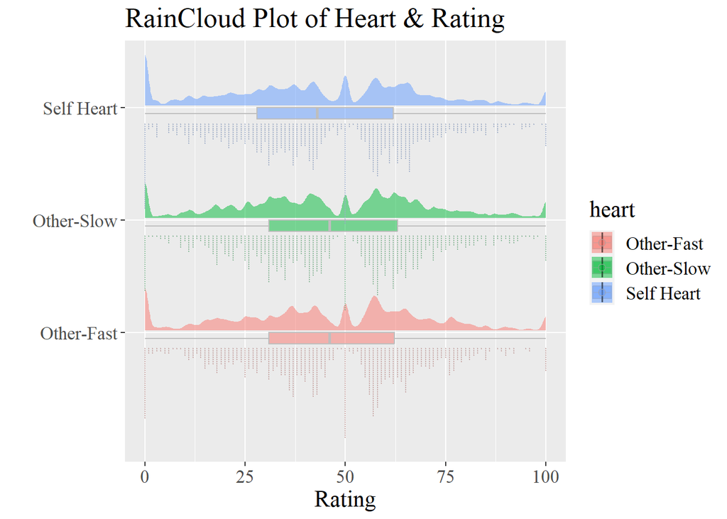

```r
ggsave(filename = "./picture/chp11/plot1.png", plot = p[[1]], height = 5, width = 10, dpi = 300)

p[[2]] <- p[[1]] +
  ggplot2::coord_flip()
names(p)[2] <- "Plot Flip"; p[[2]]+theme(text=element_text(size=16,  family="serif"))
```

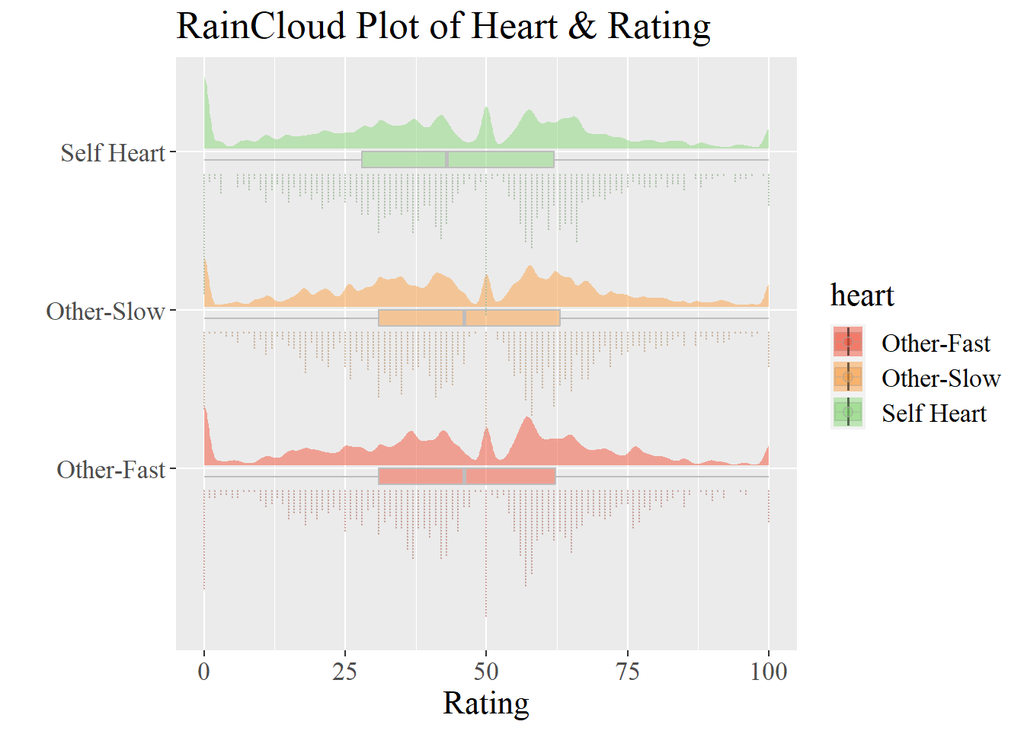

```r
ggsave(filename = "./picture/chp11/plot2.png", plot = p[[2]], height = 5, width = 10, dpi = 300)

p[[3]] <- p[[2]] +
  ggplot2::scale_fill_manual(values = palette$popsicle)  # 用什么颜色，体现了你的审美！
names(p)[3] <- "Fill Color"; p[[3]]+theme(text=element_text(size=16,  family="serif"))
```

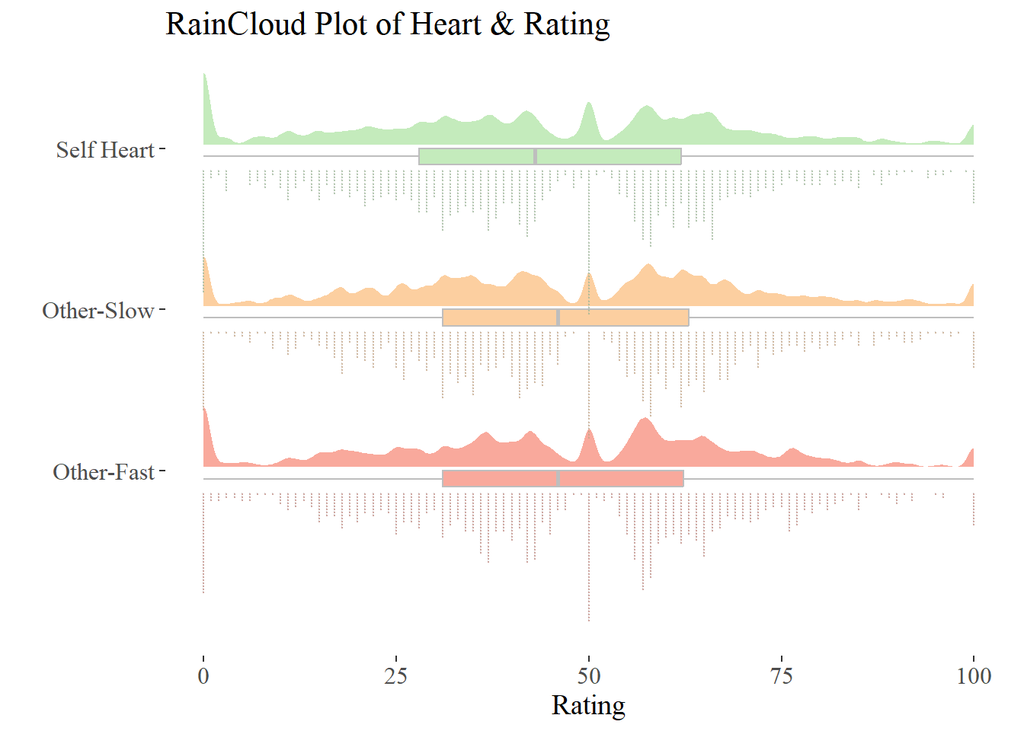

```r
ggsave(filename = "./picture/chp11/plot3.png", plot = p[[3]], height = 5, width = 10, dpi = 300)

p[[4]] <- p[[3]] +
  ggplot2::theme_bw() +
  ggplot2::theme(legend.position = "none",
                 axis.text = element_text(size = 12),
                 axis.title = element_text(size = 14),
                 strip.text = element_text(size = 14),
                 plot.title = element_text(size = 16),
                 strip.background = element_blank(),
                 panel.grid.major=element_blank(),
                 panel.grid.minor=element_blank(),
                 panel.border=element_blank(),
                 text=element_text(family='Times New Roman'),
                 )
names(p)[4] <- "APA theme"; p[[4]]+theme(text=element_text(size=16,  family="serif"))
```

```r
ggsave(filename = "./picture/chp11/plot4.png", plot = p[[4]], height = 6, width = 8, dpi = 300)
```

##Analysis of variance and regression analysis

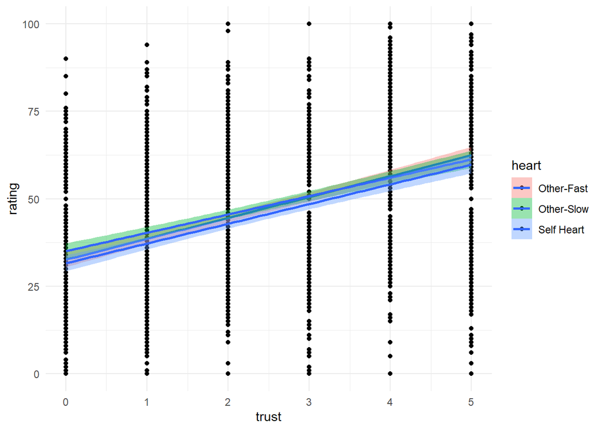

```r
 options(repos = c(CRAN = "https://cloud.r-project.org"))
 packages <- c("performance")
not_installed <- packages[!(packages %in% installed.packages()[,"Package"])]
if (length(not_installed) > 0) {
  install.packages(not_installed)
}
rm(packages,not_installed)

library(tidyverse)
install.packages("bruceR")
library(bruceR)
# 使用ggplot()画图
ggplot(T2.1, aes(x = trust, y = rating, fill = heart)) +
  geom_point() +
  geom_smooth(method = "lm") +
  scale_color_discrete(name = "heart",
                       labels = c("Self Heart","Other-Slow","Other-Fast")) +
  theme_minimal()
```

```r
#模型比较
s0=lmer(rating~ (1|pic), data=T2.1)
##使用lme4包的glmer()函数进行模型拟合，rating作为因变量，pic作为随机效应，表示每个被试重复测试的数据在不同的图片上进行了多次数据采集。使用了T2.1数据集进行分析。
s1=lmer(rating~ (1|part)+(1|pic), data=T2.1)
##使用lme4包的glmer()函数进行模型拟合，rating作为因变量，part和pic作为随机效应，表示每个被试重复测试的数据在不同的图片上进行了多次数据采集其中，(1|part)表示part是随机截距，(1|pic)表示pic也是随机截距。使用了T2.1数据集进行分析。
s2=lmer(rating~ heart+ (1|part)+(1|pic), data=T2.1)
##使用lme4包的glmer()函数进行模型拟合，rating作为因变量，heart作为自变量，part和pic作为随机效应，执行了不带交互项的回归分析。其中，(1|part)表示part是随机截距，(1|pic)表示pic也是随机截距。使用了T2.1数据集进行分析。
s3=lmer(rating~ heart+trust+ (1|part)+(1|pic), data=T2.1)
##使用lme4包的glmer()函数进行模型拟合，rating作为因变量，heart和trust作为自变量，part和pic作为随机效应，执行了不带交互项的回归分析。其中，(1|part)表示part是随机截距，(1|pic)表示pic也是随机截距。使用了T2.1数据集进行分析。
s4=lmer(rating~ heart*trust+ (1|part)+(1|pic), data=T2.1)
#使用lme4包的glmer()函数进行模型拟合，rating作为因变量，heart和trust作为自变量，将自变量heart、trust和它们的交互项的一个多层次线性回归。part和pic作为随机效应，执行了不带交互项的回归分析。其中，(1|part)表示part是随机截距，(1|pic)表示pic也是随机截距。使用了T2.1数据集进行分析。
anova(s0,s1,s2,s3,s4)
```

```
## refitting model(s) with ML (instead of REML)
```

```
## Data: T2.1
## Models:
## s0: rating ~ (1 | pic)
## s1: rating ~ (1 | part) + (1 | pic)
## s2: rating ~ heart + (1 | part) + (1 | pic)
## s3: rating ~ heart + trust + (1 | part) + (1 | pic)
## s4: rating ~ heart * trust + (1 | part) + (1 | pic)
##    npar   AIC   BIC logLik deviance    Chisq Df Pr(>Chisq)
## s0    3 23706 23724 -11850    23700
## s1    4 23497 23521 -11745    23489 211.0091  1  < 2.2e-16 ***
## s2    6 23492 23527 -11740    23480   9.3937  2   0.009124 **
## s3    7 23466 23508 -11726    23452  27.6998  1  1.417e-07 ***
## s4    9 23468 23521 -11725    23450   2.2030  2   0.332380
## ---
## Signif. codes:  0 '***' 0.001 '**' 0.01 '*' 0.05 '.' 0.1 ' ' 1
```

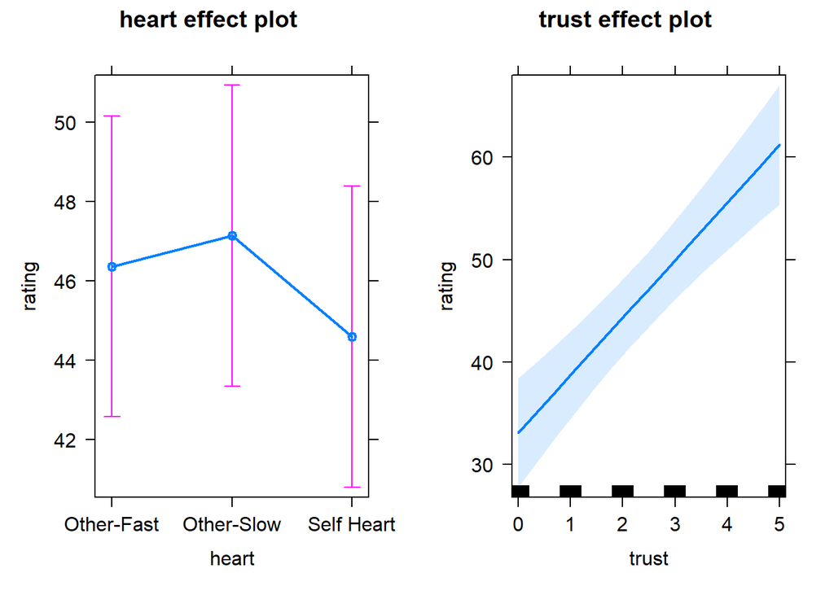

```r
plot(allEffects(s3))
```

```r
#最后比较5个模型，发现S3的回归效果最好，使用effects包的allEffects()函数，进行单变量条件效应的绘图（即rating作为因变量，heart和trust作为自变量，part和pic作为随机效应）。
```

```r
# d3拟合线性混合效应模型
s3 <- lmer(rating~ heart+trust+ (1|part)+(1|pic), data=T2.1)
# 进行方差分析
anova_result <- anova(s3)

# 输出方差分析结果
print(anova_result)
```

```
## Type III Analysis of Variance Table with Satterthwaite's method
##       Sum Sq Mean Sq NumDF DenDF F value    Pr(>F)
## heart   3078    1539     2  2639  4.7017  0.009156 **
## trust  14104   14104     1    28 43.0883 4.066e-07 ***
## ---
## Signif. codes:  0 '***' 0.001 '**' 0.01 '*' 0.05 '.' 0.1 ' ' 1
```

```r
# 提取方差分析结果的SS（平方和）和MS（均方）
SS_total <- sum(anova_result$"Sum Sq")
SS_effect <- anova_result$"Sum Sq"[2]  # 根据具体情况选择相应的效应项
df_effect <- anova_result$"Df"[2]
MS_effect <- SS_effect / df_effect

# 计算效应量
eta_squared <- SS_effect / SS_total
partial_eta_squared <- eta_squared / (1 + eta_squared)

# 输出效应量
print(eta_squared)
```

```
## [1] 0.8208605
```

```r
print(partial_eta_squared)
```

```
## [1] 0.4508091
```

##Result lower trustworthiness ratings for faces in the systole-self compared with those in the other-slow, and other-fast . No difference in the ratings given to faces in the other-slow and other-fast conditions.

linear mixed model regression analysis : only the main effect of rhythm, and not its interaction with trustworthiness, levels, was found to be significant.

#Study 3

```r
T23<- read_excel("Data_JOTandJOTD_mm.xlsx")
df.study3 <- T23 %>%
   dplyr::select(part,trial,
                 heart,
                 trust,
                 rating,
                 study
                 )%>%
  dplyr::filter(study == 3) %>%

 dplyr::mutate(heart = case_when(heart == "1" ~ "Self Heart",
                                  heart == "2" ~ "Other-Slow",
                                  heart == "3" ~ "Other-Fast")) %>%

  dplyr::group_by(heart,rating) %>%
    dplyr::ungroup()

#将T2数据框中的四个变量（part，heart，pic，study）转化为因子变量
T2$part<-factor(T2$part)
T2$heart<-factor(T2$heart)
T2$pic<-factor(T2$pic)
T2$study=factor(T2$study)
```

##Descriptive Analysis

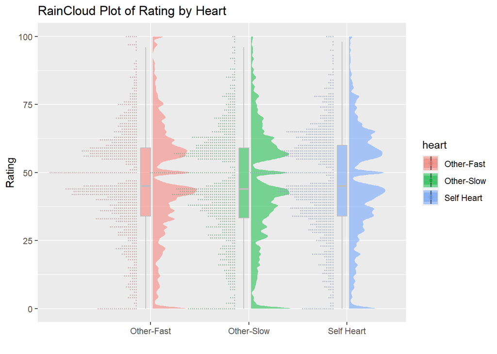

```r
p[[1]] <- ggplot2::ggplot(df.study3, aes(x = heart, y = rating, fill =heart,)) +
  ggplot2::geom_boxplot(width = 0.1, position = position_nudge(x = -0.05), color = "grey", alpha = 0.5, outlier.color = NA,) + # 箱线图左移0.2个单位
  ggdist::stat_halfeye(adjust = 0.2,justification = -0.05, alpha = 0.5, width = 0.5, .width = 0, point_colour = NA) +
  ggdist::stat_dots(side = "left",justification = 1.15, alpha = 0.5) +
  ggplot2::labs(x = "", y = "Rating", title = "RainCloud Plot of Rating by Heart")
names(p)[1] <- "RainCloud Plot"; p[[1]]
```

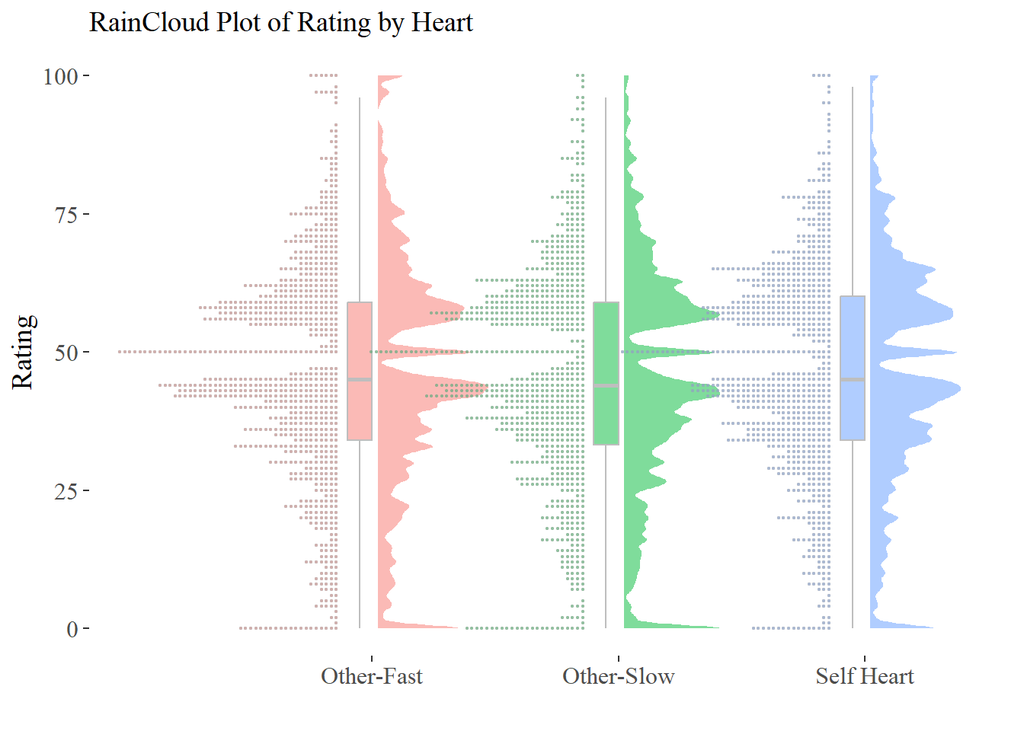

```r
ggsave(filename = "./picture/chp11/plot8.png", plot = p[[1]], height = 5, width = 10, dpi = 300)

# APA 主题
p[[2]] <- p[[1]] +
  ggplot2::theme_bw() + # 主要是为了去掉背景的灰色,
  ggplot2::theme(legend.position = "none",
                 axis.text = element_text(size = 12),
                 axis.title = element_text(size = 14),
                 strip.text = element_text(size = 14),
                 plot.title = element_text(size = 14),
                 strip.background = element_blank(), # 去掉facet标题底色
                 panel.grid.major=element_blank(), # 隐藏主要网格线
                 panel.grid.minor=element_blank(), # 隐藏次要网格线
                 panel.border=element_blank(), # 隐藏边框
                 text=element_text(family='Times New Roman'), # 字体调整为Times New Roman
                 # 使用windowsFonts()查看字体对应的名字是什么
                 # 如果没有，可以导入 extrafont 包 library(extrafont)
                 # 这个包很笨，只能添加一个文件夹内的字体，但是默认字体文件夹内"C:/WINDOWS/FONT/"字体太多了,
                 # 因此建议你把需要的字体放到桌面，然后导入font_import(path = "C:/user/desktop/")
                 # 列出已导入的字体 fonttable()，使用FamilyName就可以了
                 )
names(p)[2] <- "APA theme"; p[[2]]+theme(text=element_text(size=16,  family="serif"))
```

```r
ggsave(filename = "./picture/chp11/plot17.png", plot = p[[2]], height = 6, width = 8, dpi = 300)
```

## Methods

We report how we determined our sample size, all data exclusions (if any), all manipulations, and all measures in the study.

## Material and Procedure

The stimuli, task, and procedures were identical to those of Study 2 with the exception that in this study, stimuli in the synchronous condition were presented during cardiac diastole (R + 500 ms; diastole-self condition). This procedure preserved the frequency and heart dynamics of the previous cardio-visual stimulation procedure but introduced a phase shift (i.e., consistent delay) of the visual presentation in relation to the cardiac cycle (cf. Salomon et al., 2016). In other words, the exteroceptive and interoceptive information were still coupled, but synchrony was now achieved by presenting stimuli during the quiescent phase of the cardiac cycle. Cases with scores 2 standard deviations above or below the mean were excluded from the main analyses. One participant was excluded on this basis (note that we obtained the exact same pattern of results when including this participant in the main analyses).

## Data analysis

We used R [Version 4.2.2; @R-base] for all our analyses. The results from Frequentist hypothesis testing (i.e., ANOVA) will be reported below.

## Results

```r
#从数据框T2中选择study列等于3的行，并将结果赋值给TD
TD=T2[which(T2$study==3),]

#对数据框TD中的trial变量进行标准化处理，并将处理结果赋值给TD$trial
TD$trial<-scale(TD$trial,center=TRUE,scale= TRUE)

##模型比较
#使用lmer函数建立一个线性混合效应模型（Linear Mixed Effects Model）;rating~(1|pic)：指定了模型的公式，即rating作为响应变量，pic作为随机效应变量;(1|pic)表示在pic变量水平上引入一个随机截距项，表示每个pic水平上存在一个随机效应;data=TD：指定了模型的数据来源，即数据框TD。将这个模型建立后，可以通过调用d0来访问模型的结果，包括固定效应估计、随机效应估计、模型拟合优度等等。
d0=lmer(rating~(1|pic), data=TD)
#建立了一个线性混合效应模型，用于分析rating变量与part和pic两个因子之间的关系。模型中的rating~ (1|part)+(1|pic)表示rating变量作为响应变量，同时考虑了part和pic作为随机效应变量。(1|part)表示在part变量水平上引入一个随机截距项，表示每个part水平上存在一个随机效应；(1|pic)表示在pic变量水平上引入一个随机截距项，表示每个pic水平上存在一个随机效应。数据来源为TD数据框。通过建立这个模型，可以分析rating变量与part和pic之间的关系，并可以获取模型的结果，如固定效应估计、随机效应估计、模型拟合优度等。
d1=lmer(rating~ (1|part)+(1|pic), data=TD)
#建立了一个线性混合效应模型，用于分析rating变量与heart、part和pic三个因子之间的关系。其中，heart是作为固定效应变量，part和pic是作为随机效应变量。模型的优化算法使用了"bobyqa"，并设置了最大迭代次数为2e5。
d2=lmer(rating~ heart+ (1|part)+(1|pic), data=TD,control=lmerControl(optimizer="bobyqa",optCtrl=list(maxfun=2e5)))
#anova(d0, d1, d2)是一个用于比较三个线性混合效应模型（d0, d1, d2）之间的拟合优度的函数。
anova(d0,d1,d2)
```

```
## refitting model(s) with ML (instead of REML)
```

```
## Data: TD
## Models:
## d0: rating ~ (1 | pic)
## d1: rating ~ (1 | part) + (1 | pic)
## d2: rating ~ heart + (1 | part) + (1 | pic)
##    npar   AIC   BIC logLik deviance    Chisq Df Pr(>Chisq)
## d0    3 22677 22695 -11336    22671
## d1    4 22066 22090 -11029    22058 612.9545  1     <2e-16 ***
## d2    6 22069 22104 -11028    22057   1.5286  2     0.4656
## ---
## Signif. codes:  0 '***' 0.001 '**' 0.01 '*' 0.05 '.' 0.1 ' ' 1
```

```r
#建立线性混合效应模型，rating是因变量，trust是固定效应变量，part和pic是随机效应变量
d2=lmer(rating~ trust+ (1|part)+(1|pic), data=TD)
#建立线性混合效应模型，rating是因变量，heart和trust是固定效应变量，heart:trust是交互作用项，part和pic是随机效应变量
d3=lmer(rating~ heart:trust+trust+ (1|part)+(1|pic), data=TD)

#执行anova(d0, d1, d2, d3)将比较四个线性混合效应模型（d0, d1, d2, d3）之间的拟合优度
anova(d0,d1,d2,d3)
```

```
## refitting model(s) with ML (instead of REML)
```

```
## Data: TD
## Models:
## d0: rating ~ (1 | pic)
## d1: rating ~ (1 | part) + (1 | pic)
## d2: rating ~ trust + (1 | part) + (1 | pic)
## d3: rating ~ heart:trust + trust + (1 | part) + (1 | pic)
##    npar   AIC   BIC logLik deviance    Chisq Df Pr(>Chisq)
## d0    3 22677 22695 -11336    22671
## d1    4 22066 22090 -11029    22058 612.9545  1  < 2.2e-16 ***
## d2    5 22044 22073 -11017    22034  24.7284  1  6.601e-07 ***
## d3    7 22047 22088 -11017    22033   0.4585  2     0.7951
## ---
## Signif. codes:  0 '***' 0.001 '**' 0.01 '*' 0.05 '.' 0.1 ' ' 1
```

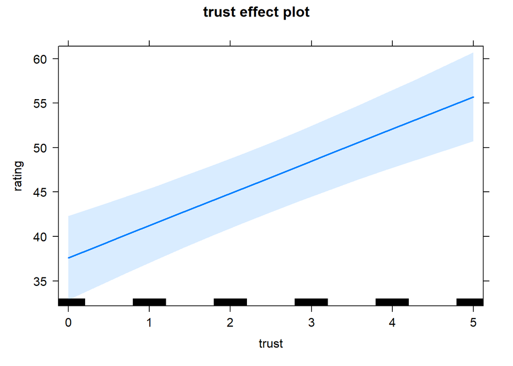

```r
#该图形显示了模型d2中所有固定效应的边际效应
plot(allEffects(d2)) # just for quick visualization not the plots in the manuscript
```

```r
##Study3方差分析和效应量计算
# d2拟合线性混合效应模型
d22<-lmer(rating~ trust+ (1|part)+(1|pic), data=TD)
# 进行方差分析
anova2_result <- anova(d22)

# 输出方差分析结果
print(anova2_result)
```

```
## Type III Analysis of Variance Table with Satterthwaite's method
##       Sum Sq Mean Sq NumDF DenDF F value    Pr(>F)
## trust 9423.1  9423.1     1    28  36.995 1.467e-06 ***
## ---
## Signif. codes:  0 '***' 0.001 '**' 0.01 '*' 0.05 '.' 0.1 ' ' 1
```

```r
# 提取方差分析结果的SS（平方和）和MS（均方）
SS_total <- sum(anova2_result$"Sum Sq")
SS_effect <- anova2_result$"Sum Sq"  # 根据具体情况选择相应的效应项
df_effect <- anova2_result$"Df"
MS_effect <- SS_effect / df_effect

# 计算效应量
eta_squared <- SS_effect / SS_total
partial_eta_squared <- eta_squared / (1 + eta_squared)

# 输出效应量
print(eta_squared)
```

```
## [1] 1
```

```r
print(partial_eta_squared)
```

```
## [1] 0.5
```

#Both Studies

```r
#对数据框T2中的trial变量进行标准化处理，并将处理结果赋值给T2$trial
T2$trial<-scale(T2$trial,center=TRUE,scale= TRUE)

##模型比较
#使用lmer函数建立一个线性混合效应模型（Linear Mixed Effects Model）;rating~(1|pic)：指定了模型的公式，即rating作为响应变量，pic作为随机效应变量;(1|pic)表示在pic变量水平上引入一个随机截距项，表示每个pic水平上存在一个随机效应;data=T2：指定了模型的数据来源，即数据框T2。将这个模型建立后，可以通过调用d0来访问模型的结果，包括固定效应估计、随机效应估计、模型拟合优度等等。
t0=lmer(rating~ (1|pic), data=T2)
#建立了一个线性混合效应模型，用于分析rating变量与part和pic两个因子之间的关系。模型中的rating~ (1|part)+(1|pic)表示rating变量作为响应变量，同时考虑了part和pic作为随机效应变量。(1|part)表示在part变量水平上引入一个随机截距项，表示每个part水平上存在一个随机效应；(1|pic)表示在pic变量水平上引入一个随机截距项，表示每个pic水平上存在一个随机效应。数据来源为TD数据框。通过建立这个模型，可以分析rating变量与part和pic之间的关系，并可以获取模型的结果，如固定效应估计、随机效应估计、模型拟合优度等。
t1=lmer(rating~ (1|part) +(1|pic), data=T2)
#建立了一个线性混合效应模型，用于分析rating变量与trust、part和pic三个因子之间的关系。其中，trust是作为固定效应变量，part和pic是作为随机效应变量。
t2=lmer(rating~ trust+ (1|part)+(1|pic), data=T2)
#建立了一个线性混合效应模型，用于分析rating变量与trust、heart、part和pic三个因子之间的关系。其中，trust、heart是作为固定效应变量，part和pic是作为随机效应变量。
t3=lmer(rating~ trust+heart+ (1|part)+(1|pic), data=T2)
#anova(t0,t1,t2,t3)是一个用于比较四个线性混合效应模型（t0,t1,t2,t3）之间的拟合优度的函数。
anova(t0,t1,t2,t3)
```

```
## refitting model(s) with ML (instead of REML)
```

```
## Data: T2
## Models:
## t0: rating ~ (1 | pic)
## t1: rating ~ (1 | part) + (1 | pic)
## t2: rating ~ trust + (1 | part) + (1 | pic)
## t3: rating ~ trust + heart + (1 | part) + (1 | pic)
##    npar   AIC   BIC logLik deviance    Chisq Df Pr(>Chisq)
## t0    3 46376 46396 -23185    46370
## t1    4 45612 45638 -22802    45604 766.6466  1  < 2.2e-16 ***
## t2    5 45586 45619 -22788    45576  27.4657  1  1.599e-07 ***
## t3    7 45588 45634 -22787    45574   2.4762  2     0.2899
## ---
## Signif. codes:  0 '***' 0.001 '**' 0.01 '*' 0.05 '.' 0.1 ' ' 1
```

```r
#建立了一个线性混合效应模型，用于分析rating变量与trust、study和pic、part四个因子之间的关系。其中，trust、study是作为固定效应变量，part和pic是作为随机效应变量。模型的优化算法使用了"bobyqa"，并设置了最大迭代次数为2e5。
t3=lmer(rating~ trust+study+ (1|part)+(1|pic), data=T2,control=lmerControl(optimizer="bobyqa",optCtrl=list(maxfun=2e5)))

#anova(t2,t3)是一个用于比较两个个线性混合效应模型（t2,t3）之间的拟合优度的函数。
anova(t2,t3)
```

```
## refitting model(s) with ML (instead of REML)
```

```
## Data: T2
## Models:
## t2: rating ~ trust + (1 | part) + (1 | pic)
## t3: rating ~ trust + study + (1 | part) + (1 | pic)
##    npar   AIC   BIC logLik deviance  Chisq Df Pr(>Chisq)
## t2    5 45586 45619 -22788    45576
## t3    6 45588 45628 -22788    45576 0.0025  1     0.9601
```

```r
#建立了一个线性混合效应模型，用于分析rating变量与trust、study、heart、part和pic五个因子之间的关系。其中，trust、study、heart是作为固定效应变量，part和pic是作为随机效应变量。
t3=lmer(rating~ trust+study+ heart+ (1|part)+(1|pic), data=T2)
#建立了一个线性混合效应模型，用于分析rating变量与trust、study、heart、part和pic五个因子之间的关系。其中，trust、study、heart是作为固定效应变量，study*heart是交互作用项，part和pic是作为随机效应变量。
t4=lmer(rating~ trust+study*heart+(1|part)+(1|pic), data=T2)
#anova(t2,t3,t4)是一个用于比较三个线性混合效应模型（t2,t3,t4）之间的拟合优度的函数。
anova(t2,t3,t4)
```

```
## refitting model(s) with ML (instead of REML)
```

```
## Data: T2
## Models:
## t2: rating ~ trust + (1 | part) + (1 | pic)
## t3: rating ~ trust + study + heart + (1 | part) + (1 | pic)
## t4: rating ~ trust + study * heart + (1 | part) + (1 | pic)
##    npar   AIC   BIC logLik deviance  Chisq Df Pr(>Chisq)
## t2    5 45586 45619 -22788    45576
## t3    8 45590 45642 -22787    45574 2.4787  3    0.47914
## t4   10 45585 45650 -22782    45565 9.1990  2    0.01006 *
## ---
## Signif. codes:  0 '***' 0.001 '**' 0.01 '*' 0.05 '.' 0.1 ' ' 1
```

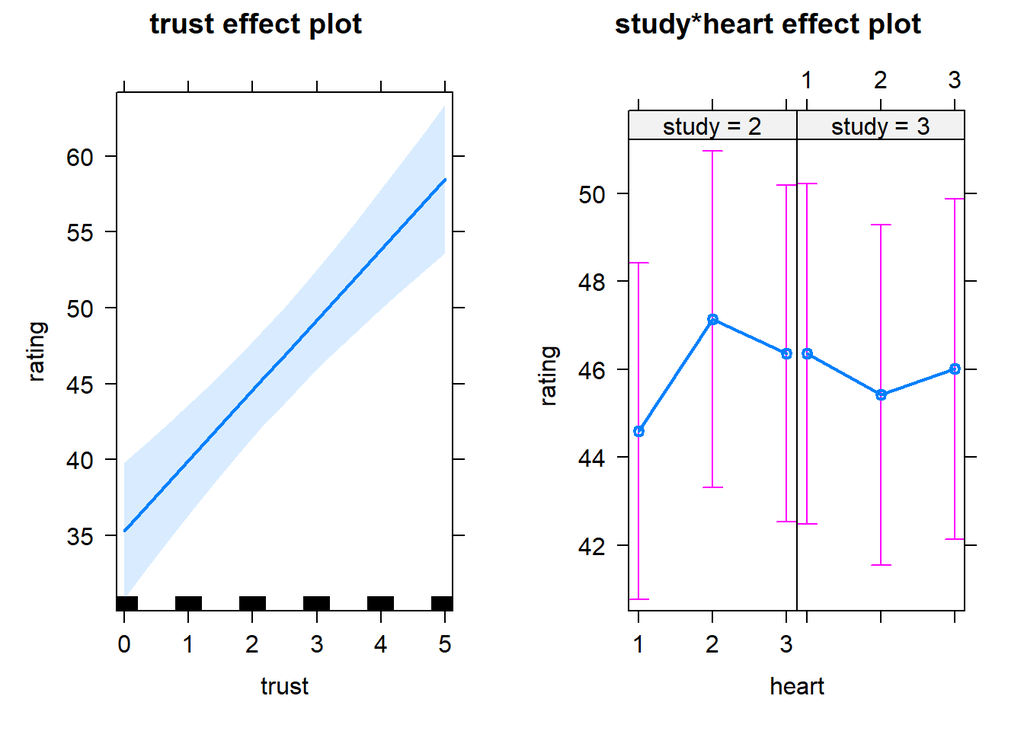

```r
#该图形显示了模型t4中所有固定效应的边际效应
plot(allEffects(t4)) # just for quick visualization not the plots in the manuscript
```

```r
# t44拟合线性混合效应模型
t4<-lmer(rating~trust+study:heart+(1|part)+(1|pic), data=T2)
```

```
## fixed-effect model matrix is rank deficient so dropping 1 column / coefficient
```

```r
# 进行方差分析
anova4_result <- anova(t4)

# 输出方差分析结果
print(anova4_result)
```

```
## Type III Analysis of Variance Table with Satterthwaite's method
##             Sum Sq Mean Sq NumDF  DenDF F value    Pr(>F)
## trust        12646 12645.6     1  28.00 42.5967 4.491e-07 ***
## study:heart   3468   693.6     5 298.86  2.3364   0.04205 *
## ---
## Signif. codes:  0 '***' 0.001 '**' 0.01 '*' 0.05 '.' 0.1 ' ' 1
```

```r
# 提取方差分析结果的SS（平方和）和MS（均方）
SS_total <- sum(anova4_result$"Sum Sq")
SS_effect <- anova4_result$"Sum Sq"[2]  # 根据具体情况选择相应的效应项
df_effect <- anova4_result$"Num DF"[2]
MS_effect <- SS_effect / df_effect

# 计算效应量
eta_squared <- SS_effect / SS_total
partial_eta_squared <- eta_squared / (1 + eta_squared)

# 输出效应量
print(eta_squared)
```

```
## [1] 0.2152209
```

```r
print(partial_eta_squared)
```

```
## [1] 0.1771043
```

#Discussion The role of cardio-visual stimulation on trustworthiness judgments.Faces presented in synchrony with the participant’s heart rhythm (at systole) were chosen less often as more trustworthy (Study 1) and were explicitly judged as less trustworthy (Study 2) than those presented asynchronously. These patterns suggest an influence of ongoing interoceptive information when people make social inferences from others’ faces. Presenting faces synchronized with the participant’s heart rhythm at diastole (Study 3) does not have an effect on participants’ judgments, indicating that the cardiac cycle phase is critical.A crucial role for the transient phasic cardiac afferent signals conveyed to the brain during systole in the modulation of social judgments.

Heightened arousal has been associated with reduced perceived trustworthiness of other people.At systole, one’s own cardiac physiological information is accentuated, when faces are presented when one is in a state of heightened physiological arousal, they are more likely to be perceived as less trustworthy.People tend to judge faces presented during systole (vs. diastole) as less trustworthy in conditions of high attentional load[@li_attention_2020].“Diastolic states” are associated with increased trust or “systolic states” are associated with decreased trust. These effects are indeed driven by phasic activity taking place during systole alone.

The specific cardio-visual effects observed on perceived trustworthiness reported here go beyond the multisensory integration process. The observed selective cardio-visual effect on trustworthiness judgments at systole is likely to go beyond simple interoceptive-exteroceptive integration and may reflect a neuromodulation of saliency and orienting systems driven by the cardiac cycle.Amygdala, an area known to mediate cardiac cycle modulations of threat processing[@garfinkel_fear_2014].

#Limitations and future directions The role of cardio-visual stimulation on the processing of other types of social inferences from faces remains unknown.

Interoceptive accuracy did not seem to relate to the observed effects. Future studies should examine whether other interoceptive dimensions, such as interoceptive sensibility or awareness[@garfinkel_knowing_2015], play a role on perceived trustworthiness or whether they interact with the phase of cardio-visual synchrony.

Cannot fully discard the possibility that other bodily changes covarying with the cardiac cycle (e.g., muscle spindle activity due to cardioballistic fluctuations)[@birznieks_modulation_2012].

#Conclusion People less often chose faces presented in synchrony with their own cardiac systole as more trustworthy than faces presented out of synchrony. People also explicitly judged faces presented in synchrony with their cardiac systole as less trustworthy. The presentation of faces in synchrony with participants’ cardiac diastole did not modulate participants’ perceptions of the faces’ trustworthiness, suggesting that the systolic phase is necessary for such interoceptive effects.

These findings highlight the role of phasic interoceptive information in the processing of social information and provide a mechanistic account of the role of visceroception for social perception.

#The reasons for this study are selected The data processing method used in this study is relatively basic, and has reference significance for our future data processing.

This study analyzes the trustworthiness of human face from the perspective of interperception, which opens a new idea for our future research.

#Division of labor It was agreed that we would each be responsible for one, Shen Tong for study 1 and introduction, Xi Yue for study 2 and presentation, and Yao Menghan for study 3 and discussion.